# Coder House

Avances del Proyecto Final

Maximiliano Galoto

# 1 - Descripcion del proyecto

*Temática para el trabajo final:*

Diagrama de Entidad de Relación de una *Empresa de Medicina Prepaga*.

# 2 - Descripción de las tablas

*Tablas, descripción y atributos:*

A continuación se detallaran cada una de las tablas que componen el DER con sus atributos y descripciones:

$$\textbf{Tabla: Afiliado }$$
|

| $$\textbf{Atributos}$$ | $$\textbf{Descripcion}$$ |
| --- | --- |
| $$Id\:Afiliado$$ | $$INT \:NOT\: NULL\: PRIMARY \:KEY\: AUTO\:INCREMENT$$ |
| $$Nombre$$ | $$VARCHAR(50) \:NOT \:NULL$$ |
| $$Apellido$$ | $$VARCHAR(50) \:NOT \:NULL$$ |
| $$Email$$ | $$VARCHAR(50) \:NOT \:NULL$$ |
| $$Telefono$$ | $$INT \:NOT \:NULL$$ |
| $$Fecha\:Nacimiento$$ | $$DATE \:NOT \:NULL$$ |
| $$Domicilio$$ | $$VARCHAR(50) \:NOT \:NULL$$ |
| $$Ocupacion$$ | $$VARCHAR(50) \:NOT \:NULL$$ |
| $$Estado\:Civil$$ | $$VARCHAR(50) \:NOT \:NULL$$ |
| $$Plan$$ | $$VARCHAR(50) \:NOT \:NULL$$ |
| $$Plan$$ | $$VARCHAR(50) \:NOT \:NULL$$ |
| $$Dni$$ | $$INT \:NOT \:NULL$$ |

*Esta tabla contiene los atributos de los afiliados a la empresa de medicina prepaga, podemos observar el ID como Primary Key, Nombre, Apellido, Fecha de Nacimiento, Domicilio, Ocupación y Estado Civil. Estos datos salen del transaccional cuando el afiliado se da de alta en nuestro sistema.*

$$\textbf{Tabla: Especialidad }$$
|

| $$\textbf{Atributos}$$ | $$\textbf{Descripcion}$$ |
| --- | --- |
| $$Id\:Especialidad$$ | $$INT \:NOT\: NULL\: PRIMARY \:KEY\: AUTO\:INCREMENT$$ |
| $$Especialidad$$ | $$VARCHAR(50) \:NOT \:NULL$$ |

*Esta tabla contiene las diferentes prestaciones que proveen los distintos centros médicos.*

$$\textbf{Tabla: Medico }$$
|

| $$\textbf{Atributos}$$ | $$\textbf{Descripcion}$$ |
| --- | --- |
| $$Id\:Medico$$ | $$INT \:NOT\: NULL\: PRIMARY \:KEY\: AUTO\:INCREMENT$$ |
| $$Nombre$$ | $$VARCHAR(50) \:NOT \:NULL$$ |
| $$Apellido$$ | $$VARCHAR(50) \:NOT \:NULL$$ |
| $$Fecha\:Nacimiento$$ | $$DATE \:NOT \:NULL$$ |
| $$Domicilio$$ | $$VARCHAR(50) \:NOT \:NULL$$ |
| $$Telefono$$ | $$INT \:NOT\: NULL$$ |

*Esta tabla contiene los datos de los médicos que prestan su servicio a distintos centros médicos.*

$$\textbf{Tabla: Plan Familiar }$$
|

| $$\textbf{Atributos}$$ | $$\textbf{Descripcion}$$ |
| --- | --- |
| $$Id\:Plan\:Familiar$$ | $$INT \:NOT\: NULL\: PRIMARY \:KEY\: AUTO\:INCREMENT$$ |
| $$Tipo$$ | $$VARCHAR(50) \:NOT \:NULL$$ |
| $$Fecha\:Alta$$ | $$DATE \:NOT \:NULL$$ |
| $$Total\:Consultas$$ | $$INT \:NOT \:NULL$$ |

$$\textbf{Tabla: Centro Medico }$$
|

| $$\textbf{Atributos}$$ | $$\textbf{Descripcion}$$ |
| --- | --- |
| $$Id\:Centro$$ | $$INT \:NOT\: NULL\: PRIMARY \:KEY\: AUTO\:INCREMENT$$ |
| $$Nombre$$ | $$VARCHAR(50) \:NOT \:NULL$$ |
| $$Dirección$$ | $$VARCHAR(50) \:NOT \:NULL$$ |
| $$Teléfono$$ | $$INT \:NOT \:NULL$$ |
| $$Cod Postal$$ | $$INT \:NOT \:NULL$$ |
| $$Email$$ | $$VARCHAR(50) \:NOT \:NULL$$ |

$$\textbf{Tabla: Consulta }$$
|

| $$\textbf{Atributos}$$ | $$\textbf{Descripcion}$$ |
| --- | --- |
| $$Id\:Consulta$$ | $$INT \:NOT\: NULL\: PRIMARY \:KEY\: AUTO\:INCREMENT$$ |
| $$Consulta$$ | $$VARCHAR(50) \:NOT \:NULL$$ |
| $$Diagnostico$$ | $$VARCHAR(50) \:NOT \:NULL$$ |

$$\textbf{Tabla: Turnos }$$
|

| $$\textbf{Atributos}$$ | $$\textbf{Descripcion}$$ |
| --- | --- |
| $$Id\:Turno$$ | $$INT \:NOT\: NULL\: PRIMARY \:KEY\: AUTO\:INCREMENT$$ |
| $$Fecha$$ | $$DATE \:NOT \:NULL$$ |
| $$Id\: Medico$$ | $$INT \:NOT\: NULL\: FOREIGN \:KEY$$ |
| $$Id\: Especialidad$$ | $$INT \:NOT\: NULL\: FOREIGN \:KEY$$ |
| $$Id\: Afiliado$$ | $$INT \:NOT\: NULL\: FOREIGN \:KEY$$ |
| $$Id\: Consulta$$ | $$INT \:NOT\: NULL\: FOREIGN \:KEY$$ |
| $$Id\:Plan\:Familiar$$ | $$INT \:NOT\: NULL\: FOREIGN \:KEY$$ |
| $$Id\:Centro$$ | $$INT \:NOT\: NULL\: FOREIGN \:KEY$$ |

*Esta tabla conecta el medico y el paciente, donde podemos ver la consulta, la fecha y el diagnostico. Cada turno tiene un Id.*

# 3 - Diagrama Entidad de Relacion

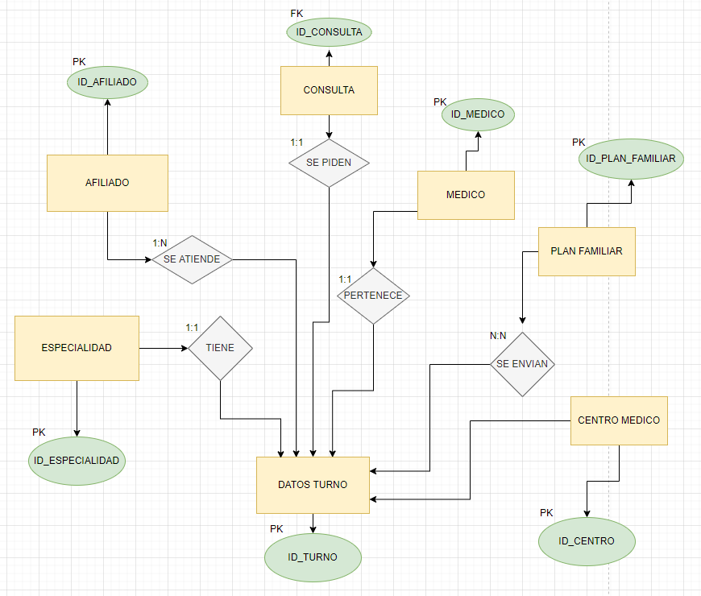

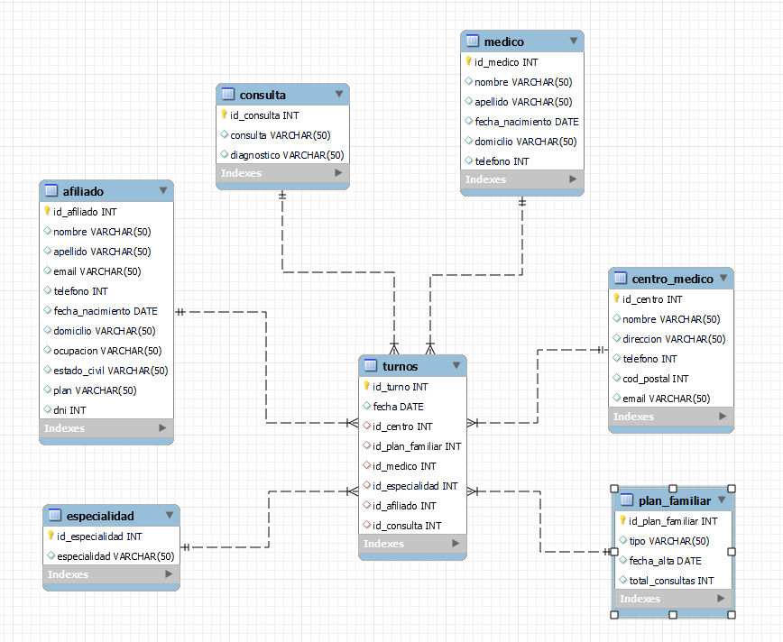

# 4 - Codigo MySql desde Python

[Github Codigo](https://github.com/MGaloto/mysql_creando_database/blob/main/database.py)

# 5 - Inserción de datos

*Metodologia utilizada:*

Los valores en cada una de las tablas se insertaron desde archivos .csv.

Los archivos son los siguientes:

[figure not shown]

*Cada una de las tablas contiene 10 observaciones*

*Ejemplo tabla afiliados:*

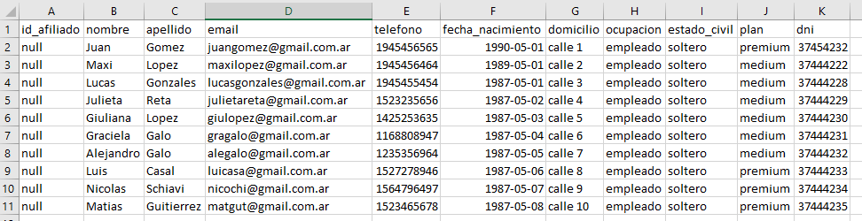

A continuación se adjuntan scripts de los pasos para importar los datos y MySql final:

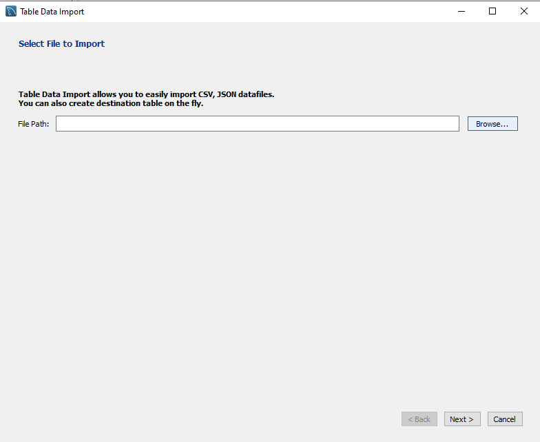

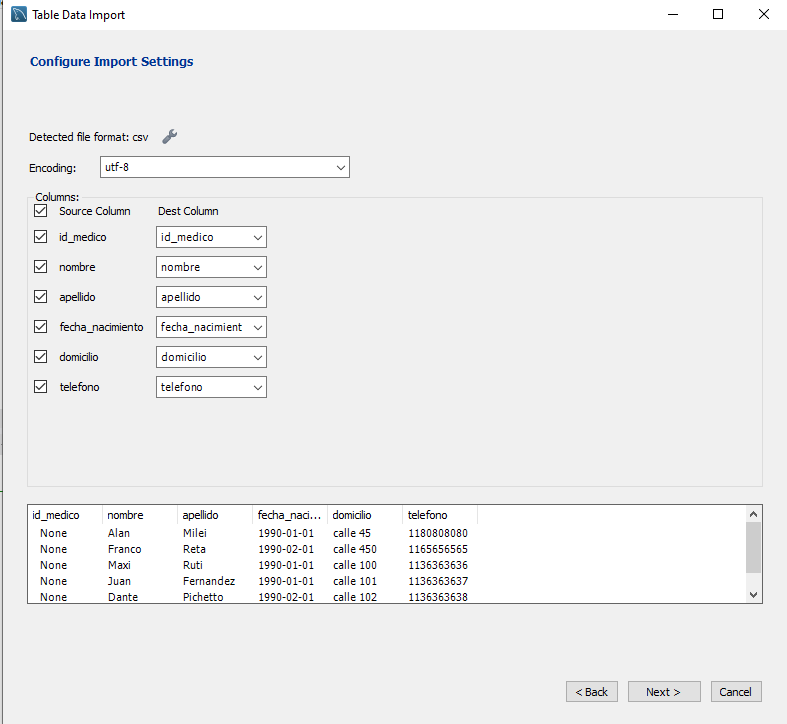

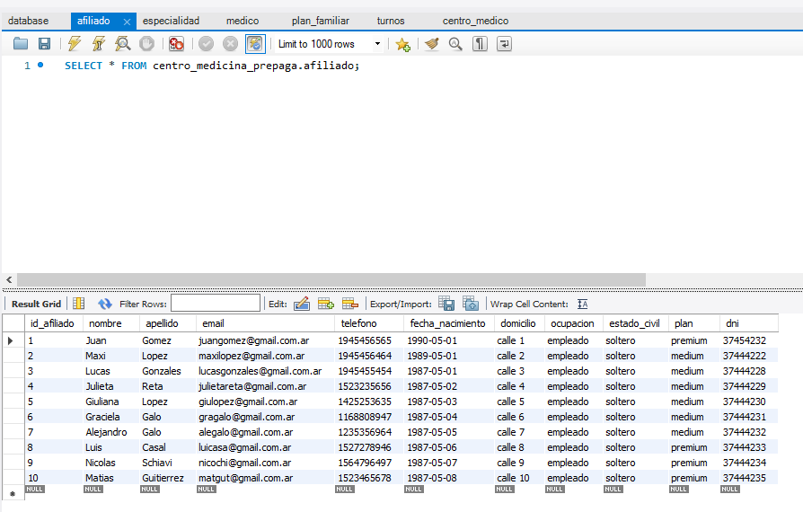

# 6 - Vistas

*A continuación se adjuntan los scripts de las 5 vistas*

*El código SQL de las vistas se encuentra en el siguiente link:* [Github Codigo](https://github.com/MGaloto/mysql_creando_database/blob/main/database.py)

*1) Vista 1:*

*Consulta y Diagnostico por Afiliado*

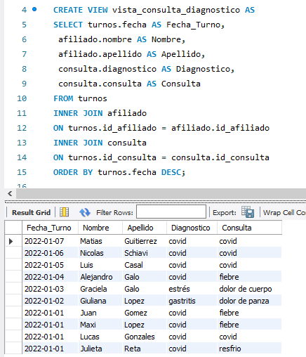

*2) Vista 2*

*Que medico atendió a cada paciente:*

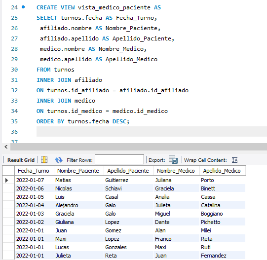

*3) Vista 3*

*Que medico atiende en cada centro medico:*

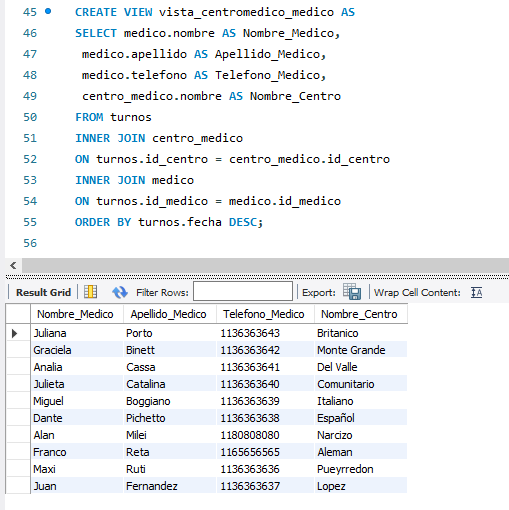

*4) Vista 4*

*Plan familiar por afiliado:*

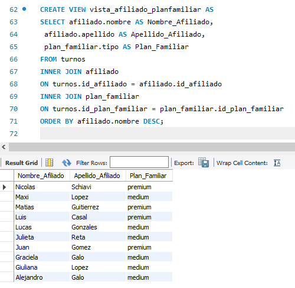

*5) Vista 5*

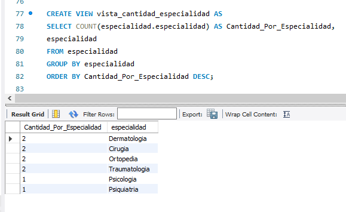

# 7 - Funciones

*A continuación se adjuntan los scripts de las funcioness*

*1) Función 1:*

*Función donde ingresamos un CHAR y nos devuelve un NUMERIC*

*Ingresamos el diagnostico y nos regresa el porcentaje de pacientes con el diagnostico ingresado de nuestra base de datos*

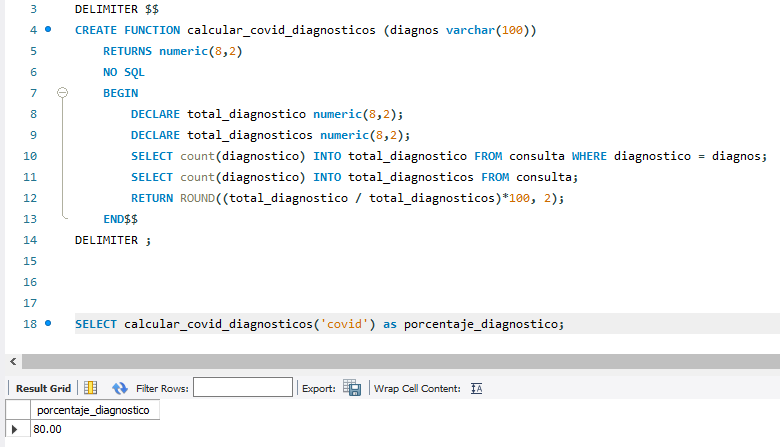

*2) Función 2:*

*Función donde ingresamos un CHAR y nos devuelve un NUMERIC*

*Ingresamos el plan familiar y nos regresa el porcentaje de afiliados con el plan familiar ingresado de nuestra base de datos*

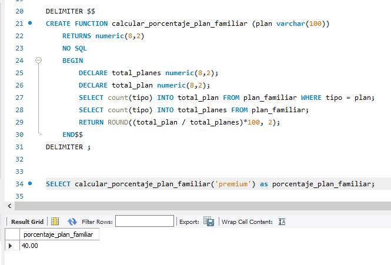

# 8 - Stored Procedures

*A continuación se adjuntan los scripts de los Stored Procedures*

*1) Stored Procedure 1:*

*En el siguiente Stored Procedure se ejecuta un comando que ordena una variable de forma descendente o ascendente. Los parametros permiten elegir el orden, la tabla y la variable.*

[figure not shown]

*2) Stored Procedure 2:*

*El siguiente Stored Procedure ejecuta un comando para actualizar la tabla Turnos.*

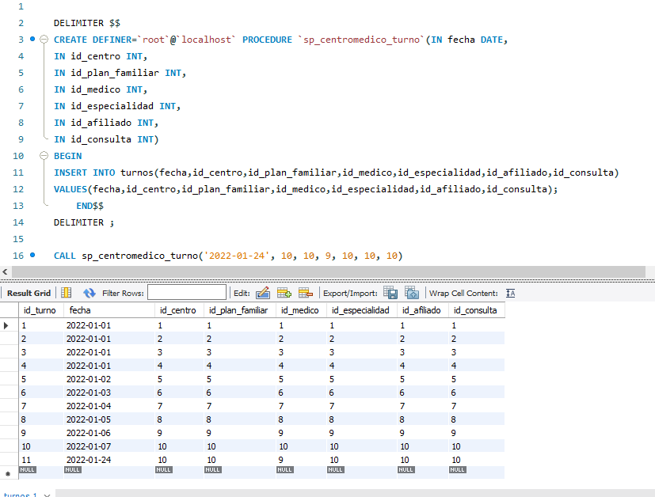